# Project 2 - Part II

## Enviornmental Trends in the 21st Century

### Student ID: 004002088

Dataset Reference: https://www.kaggle.com/datasets/adilshamim8/temperature?resource=download

## Importing Data

Firstly, I started by importing all my libraries. Then I read in the csv file with the information and used the head() function to make sure I imported the correct data file. In its current state, the data is unfiltered, unorganized, and unclean.

```python
# importing all the libraries
import pandas as pd
import numpy as np
import seaborn as sns
import matplotlib.pyplot as plt

df = pd.read_csv("temperature.csv") # open the data file

df.head() # making sure we have the correct data
```

|  | Year | Country | Avg_Temperature_degC | CO2_Emissions_tons_per_capita | Sea_Level_Rise_mm | Rainfall_mm | Population | Renewable_Energy_pct | Extreme_Weather_Events | Forest_Area_pct |
| --- | --- | --- | --- | --- | --- | --- | --- | --- | --- | --- |
| 0 | 2006 | UK | 8.9 | 9.3 | 3.1 | 1441 | 530911230 | 20.4 | 14 | 59.8 |
| 1 | 2019 | USA | 31.0 | 4.8 | 4.2 | 2407 | 107364344 | 49.2 | 8 | 31.0 |
| 2 | 2014 | France | 33.9 | 2.8 | 2.2 | 1241 | 441101758 | 33.3 | 9 | 35.5 |
| 3 | 2010 | Argentina | 5.9 | 1.8 | 3.2 | 1892 | 1069669579 | 23.7 | 7 | 17.7 |
| 4 | 2007 | Germany | 26.9 | 5.6 | 2.4 | 1743 | 124079175 | 12.5 | 4 | 17.4 |

## Cleaning the Data

Next, the data must be cleaned and organized. I noticed that there were often multiple entires per year per country. For example, in the year 2000, South Africa had 7 entries. If each entry had a month associated with them, that might be useful, but because we do not know when in the year the data was collected, I wanted to consolidate the information so there was only one entry, per country per year. I started by using the groupby feature to organize first by year, then by country. Then, the rows were aggregated based on either mean or max, depending on what was more appropriate per column. For example, it was best to average it for the Average Temperature, but it was better to find the max for Sea Level Rise since that was likely taken later in the year. This grouping also sorts the data by year so the entries go from oldest to most recent.

```python
df_grouped = df.groupby(["Year", "Country"]).agg({"Avg_Temperature_degC" : 'mean',
                                                      "CO2_Emissions_tons_per_capita" : 'mean',
                                                      "Sea_Level_Rise_mm" : 'max',
                                                      "Rainfall_mm" : 'max',
                                                      "Population" : 'mean',
                                                      "Renewable_Energy_pct" : 'mean',
                                                      "Extreme_Weather_Events" : 'max',
                                                      "Forest_Area_pct" : 'mean'
                                                    }).reset_index() # sorts the data and aggregates it, using either mean or max

df_grouped.head()
```

|  | Year | Country | Avg_Temperature_degC | CO2_Emissions_tons_per_capita | Sea_Level_Rise_mm | Rainfall_mm | Population | Renewable_Energy_pct | Extreme_Weather_Events | Forest_Area_pct |
| --- | --- | --- | --- | --- | --- | --- | --- | --- | --- | --- |
| 0 | 2000 | 'South Africa' | 26.114286 | 13.985714 | 4.6 | 2762 | 539231125.0 | 25.414286 | 14 | 32.514286 |
| 1 | 2000 | Argentina | 16.900000 | 3.900000 | 4.0 | 2047 | 564877556.0 | 15.500000 | 11 | 18.400000 |
| 2 | 2000 | Australia | 11.933333 | 10.466667 | 3.9 | 2834 | 831776454.0 | 25.566667 | 13 | 58.133333 |
| 3 | 2000 | Brazil | 31.200000 | 14.600000 | 3.7 | 803 | 255339962.0 | 28.300000 | 9 | 21.700000 |
| 4 | 2000 | Canada | 19.300000 | 8.850000 | 3.1 | 2279 | 414931290.5 | 22.750000 | 14 | 42.100000 |

## Feature Engineering

Now that the data was a bit more consolidated, I decided to add some features. Firstly, a variable called "Abv_Avg_Events" returned either a 0 or 1 depending on if the entry had an above or below median number of extreme weather events. This felt useful for putting the number of extreme weather events in context.

Next, I created a categorical "climate" variable. Depending on the range the average temperature fell in, it would classify the climate as warm, temperate or cold. This could be useful for quickly determining if the average temperature in a country has changed signficantly.

Lastly, I added a categorical "region" variable. It simply filters based on the continent the country is on. This is a really helpful groupby variable.

```python
df_new = df_grouped.copy() # copies the df to a new dataframe

df_new['Abv_Avg_Events'] = (df_new['Extreme_Weather_Events'] >= df_new['Extreme_Weather_Events'].median()).astype(int) # works like a boolean that is 1 if the number of events is greater than the median

def climate(temp): # simple if else for classifying the climate based on temp
    if temp >= 22:
        return "Warm"
    elif temp >= 12:
        return "Temperate"
    else:
        return "Cold"
df_new['Climate'] = df_new['Avg_Temperature_degC'].apply(climate)

def region(country): # takes the string and sorts it using the if else, returning the region. this is not feasible for larger sets but it worked fine for this set of only 14 countries
    if country == "UK" or country == "Germany" or country == "France" or country == "Russia":
        return "Europe"
    elif country == "'South Africa'":
        return "Africa"
    elif country == "Australia":
        return "Oceania"
    elif country == "Mexico" or country == "Argentina" or country == "Brazil":
        return "South America"
    elif country == "Canada" or country == "USA":
        return "North America"
    elif country == "India" or country == "Japan" or country == "Indonesia" or country == "China":
        return "Asia"
df_new['Region'] = df_new['Country'].apply(region)
```

```python
df_new.to_csv("temperature_cleaned.csv") # exports the cleaned dataframe to a new csv
df_new.head() # displays so we can check to see if it's sorted appropiately
```

|  | Year | Country | Avg_Temperature_degC | CO2_Emissions_tons_per_capita | Sea_Level_Rise_mm | Rainfall_mm | Population | Renewable_Energy_pct | Extreme_Weather_Events | Forest_Area_pct | Abv_Avg_Events | Climate | Region |
| --- | --- | --- | --- | --- | --- | --- | --- | --- | --- | --- | --- | --- | --- |
| 0 | 2000 | 'South Africa' | 26.114286 | 13.985714 | 4.6 | 2762 | 539231125.0 | 25.414286 | 14 | 32.514286 | 1 | Warm | Africa |
| 1 | 2000 | Argentina | 16.900000 | 3.900000 | 4.0 | 2047 | 564877556.0 | 15.500000 | 11 | 18.400000 | 1 | Temperate | South America |
| 2 | 2000 | Australia | 11.933333 | 10.466667 | 3.9 | 2834 | 831776454.0 | 25.566667 | 13 | 58.133333 | 1 | Cold | Oceania |
| 3 | 2000 | Brazil | 31.200000 | 14.600000 | 3.7 | 803 | 255339962.0 | 28.300000 | 9 | 21.700000 | 0 | Warm | South America |
| 4 | 2000 | Canada | 19.300000 | 8.850000 | 3.1 | 2279 | 414931290.5 | 22.750000 | 14 | 42.100000 | 1 | Temperate | North America |

## Boxplot: CO2 Emissions per Region

This boxplot shows the CO2 emissions of the data, grouped by region, and then further grouped by an above or below average number of extreme weather events. When we evaluate the graph we can see that the range of values in North America, Europe, and South America are the largest while Oceania and Africa have the smallest range of values. This is likely due to the number of countries included in each region. The data only takes from 15 countries, with Oceania and Africa being vastly underrepresented. Both regions have one country each. Therefore, there's less variance in their data. In most regions, data points that have an above average amount of extreme weather events actually tend to have lower average CO2 emissions. However, there is much more variance in the CO2 emissions of the data that have below average extreme weather events. Latly, across the board, Oceania and Africa tend to have lower emissions than the other regions while North America, Asia, and Europe tend to have the most.

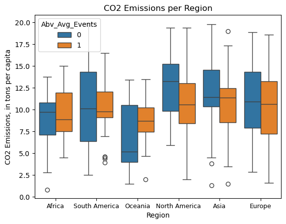

```python
sns.boxplot(data=df_new, x="Region", y="CO2_Emissions_tons_per_capita", hue = "Abv_Avg_Events") #creates a boxplot
plt.title("CO2 Emissions per Region") # titles graph
plt.ylabel("CO2 Emissions, in tons per capita") # changes y-axis label
plt.xticks(size=9) # makes x-axis text a bit smaller
plt.show()
```

## Bar chart: Extreme Weather Events by Region

This chart shows extreme weather events grouped by region, and then further grouped by climate. Firstly, I find it interesting that in most regions, temperate regions have the highest number of extreme weather events, usually followed by warm climates, and then cold climates. Additionally, Oceania has the widest ranges in values, meaning their weather may be more unpredictable, year to year. Swings and changes in climate are generally a sign of climate change. In general, most cold climates have a larger swing in values. Cold weather is a bit more unpredictable than warm weather and is less correlated to extreme weather events, so it makes sense that the values for cold climates has a wider spread.

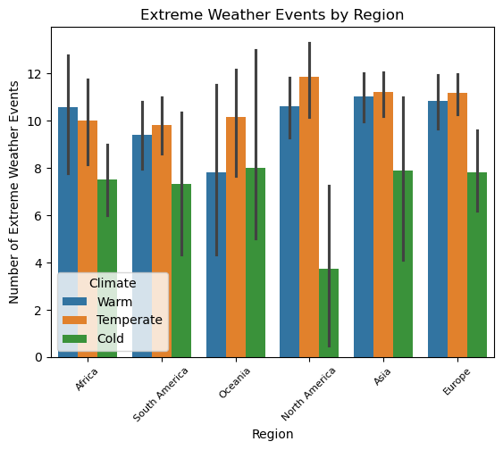

```python
sns.barplot(data=df_new, x="Region", y="Extreme_Weather_Events", hue="Climate") # create barplot
plt.title("Extreme Weather Events by Region") # change title
plt.ylabel("Number of Extreme Weather Events") # change y-axis label
plt.xticks(size=8, rotation=45) # allows more space for the x-axis label
plt.show()
```

## Bar plot: CO2 Emissions by Country

This barplot plots the CO2 emissions of each country, sorted from least to most. The y-axis of this graph is adjusted, starting from 6 instead of 0, in order to better show the differences between the data. The first thing I noticed is that Australia has a drastically lower value for CO2 emissions compared to every other country. There's a jump of almost an entire ton before reaching to next country. Secondly, the UK seems to also have a drastic difference compared to its next country. The jump from the UK down to the USA is smaller, but still significant. There are small clusters of countries that have very similar values like Mexico, South Africa and Russia for example. It can be inferred that countries producing the same amount of emissions per capita are in similar stages of development and manufacturing. The more manufacturing, the more emissions. The countries with the most emissions also tend to be huge importers, just based on prior knowledgee about France, Brazil, the US and the UK. If the data allowed it, I would like to see a comparison between imports and CO2 emissions.

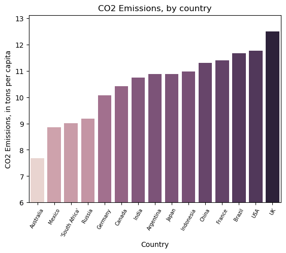

```python
df_cou = df_new.groupby("Country").agg({"Avg_Temperature_degC" : 'mean',
                                                      "CO2_Emissions_tons_per_capita" : 'mean',
                                                      "Sea_Level_Rise_mm" : 'mean',
                                                      "Rainfall_mm" : 'mean',
                                                      "Population" : 'mean',
                                                      "Renewable_Energy_pct" : 'mean',
                                                      "Extreme_Weather_Events" : 'mean',
                                                      "Forest_Area_pct" : 'mean'}) # regroups the data by country across the board

sns.barplot(data=df_cou.sort_values("CO2_Emissions_tons_per_capita"), y="CO2_Emissions_tons_per_capita", x="Country",hue="CO2_Emissions_tons_per_capita", legend = False )
plt.xticks(rotation = 60, size = 7) # rotates the x-axis labels to allow more space
plt.ylabel("CO2 Emissions, in tons per capita") # changing the y-axis label
plt.title("CO2 Emissions, by country") # titling the dataset
plt.ylim(6) #limits the y-axis to better show the differences
plt.show()
```

## Scatter plot: Sea Level Rise and Above Average Events Over Time

This scatter plot takes a look at the year versus sea level rise, in mm, with an additional filtering of above average extreme weather events. The entire graph is clustered towards the top, with the higher amount of sea level rise, but the data gets a little more clustered towards the top as the year continues. There is only value at the minimum, as shown in the graph, but there are several points at the maximum. The minimum has a below average amount of extreme weather events while nearly every maximum, with the exception of 2, has an above average amount of extreme events. If you were to use your hand to cover the top half of the graph, the bottom half of the graph is mostly points that have a below average amount of extreme events. The top half of the graph is a bit more evenly distributed. There is likely not a very strong correlation between these variables, but there is certainly a correlation.

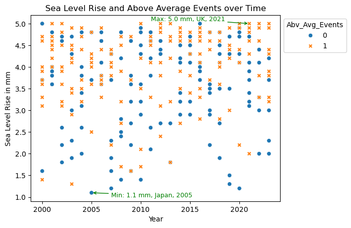

```python
slrot = sns.scatterplot(x="Year", y="Sea_Level_Rise_mm", data=df_corr, hue="Abv_Avg_Events", style="Abv_Avg_Events") # creates scatter plot
sns.move_legend(slrot, "upper left", bbox_to_anchor=(1, 1)) # moves the legend away from the chart to increase clarity

plt.title("Sea Level Rise and Above Average Events over Time") # adds title
plt.xlabel("Year")
plt.ylabel("Sea Level Rise in mm")
mini = df_new.loc[df_new['Sea_Level_Rise_mm'].idxmin()] # will store the value of the minimum
# maxi = df_corr.loc[df_corr['Sea_Level_Rise_mm'].idxmax()]
maxi = df_new.loc[df_new['Sea_Level_Rise_mm'].nlargest(11).index[10]] # will store the value of the maximum
plt.annotate( # annotes the minimum
    f"Min: {mini['Sea_Level_Rise_mm']} mm, {mini['Country']}, {mini['Year']}",
    xy = (mini['Year'], mini['Sea_Level_Rise_mm']),
    xytext = (mini['Year'] + 2, mini['Sea_Level_Rise_mm'] - 0.1),
    arrowprops=dict(arrowstyle="->", color='green'),
    fontsize = 9,
    color = "green"
)
plt.annotate( # annotates the maximum
    f"Max: {maxi['Sea_Level_Rise_mm']} mm, {maxi['Country']}, {maxi['Year']}",
    xy = (maxi['Year'], maxi['Sea_Level_Rise_mm']),
    xytext = (maxi['Year'] - 10, maxi['Sea_Level_Rise_mm'] + 0.06),
    arrowprops=dict(arrowstyle="->", color='green'),
    fontsize = 9,
    color = "green"
)
plt.show()
```

## Correlation matrix

A lot of these correlations make perfect sense, as our knowledge of climate change informs us that rainfall and the level of the sea are part of the same system that cause them to be related to one another, even if they don't directly relate. Sea level has also consistently been an indicator of other much larger issues with climate change, due to the effects that climate change has on our very delicate glaciers. Average temps and renewable energy being inversely, specifically, related makes perfect sense. The purpose of renewable energy is to free us from the effects of fossil fuels, which are known to release CO2 and cause the atmosphere to heat up. Population and renewable energy being inversely correlated is actually very surprising to me. It's interesting that countries that are larger actually tend to have less renewable energy.

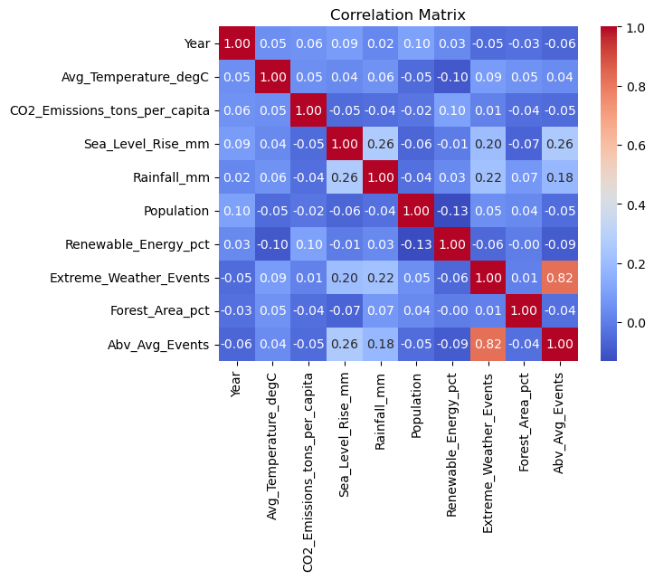

```python
corr_matrix = df_new.corr(numeric_only = True) # creates correlation matrix table
sns.heatmap(corr_matrix, annot =True, cmap = "coolwarm", fmt=".2f") # plots the matrix as a heatmap
plt.title("Correlation Matrix") # adds title
plt.show()
```